# Reproducible Research: Peer Assessment 1

Georges Krinker

This document describes the loading, pre-processing and analysis of data from a personal activity monitoring device. The data consists of two months of data from an anonymous individual collected during the months of October and November, 2012 and include the number of steps taken in 5 minute intervals each day.

In this document we will perform the following analysis -

1. Generate a Histogram of the total number of steps taken each day
2. Determine the mean and median total number of steps taken per day
3. Draw a time series plot of the average number of steps taken.
4. Determine the 5-minute interval that, on average, contains the maximum number of steps
5. Inpute missing data (represented in the data with NAs)
6. Generate a Histogram of the total number of steps taken each day after missing values are imputed.
7. Create a Panel plot comparing the average number of steps taken per 5-minute interval across weekdays and weekends.

## Loading and preprocessing the data

We are first going to load the data as a data frame.

```r
data <- read.csv("activity.csv")
```

In order to make our analysis easier, we are going to convert the date variable into a factor.

```r
data$date <- as.factor(data$date)
```

## What is the mean total number of steps taken per day?

Our first step in the analysis is to produce a histogram of the total number of steps across each day.

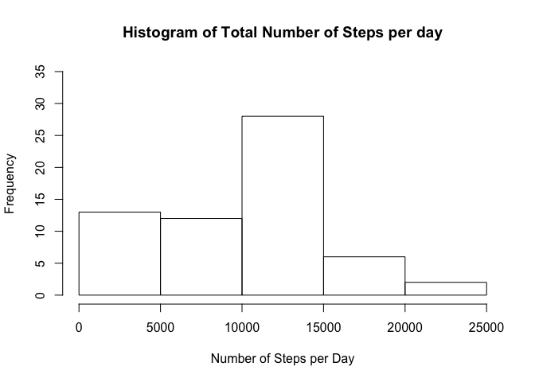

```r
stepsPerday <- aggregate(data$steps, by = list(Date = data$date), FUN = sum, na.rm = TRUE)

names(stepsPerday)[2] <- "TotalSteps"

hist(stepsPerday$TotalSteps, main = "Histogram of Total Number of Steps per day", xlab = "Number of Steps per Day", ylab = "Frequency", ylim = c(0,35))
```

Now, we calculate the mean and median steps taken per day.

```r
mean(stepsPerday$TotalSteps)
```

```
## [1] 9354.23
```

```r
median(stepsPerday$TotalSteps)
```

```
## [1] 10395
```

## What is the average daily activity pattern?

We first aggregate for the average (interpreted as mean) over the 5 minute intervals across days.

```r
AverageStepsByInterval = aggregate(data$steps, by = list(data$interval), FUN = mean, na.rm = TRUE)
```

Now we plot a time series (type = ‘l’) of the average number of steps of each interval across days.

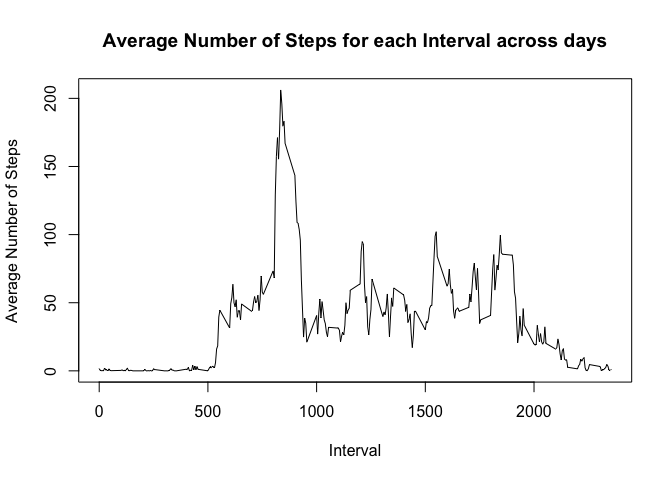

```r
plot(AverageStepsByInterval[[1]], AverageStepsByInterval[[2]], type="l", ylab = "Average Number of Steps", xlab = "Interval", main = "Average Number of Steps for each Interval across days")
```

```r
##Sort by highest average across days
SortedAverageStepsByInterval <- AverageStepsByInterval[order(AverageStepsByInterval[[2]]),]

##return interval in first row of sorted data frame
SortedAverageStepsByInterval[1,1]
```

```
## [1] 40
```

## Imputing missing values

There is a total of 2304 NAs in the dataset.

We are going to fill in all the missing values (NAs) of the original dataset by substituting each missing value with the average for that interval across days.

```r
## We'll go through each row of the table and if NA, replace it with the average for that interval across days

dataWithNoNa <- data;

for (i in 1:nrow(dataWithNoNa)){
        if(is.na(dataWithNoNa[i,1])){
                dataWithNoNa[i,1] <- AverageStepsByInterval[which(AverageStepsByInterval[[1]] == dataWithNoNa[i,3]),2]
        }
}
```

We produce a histogram with our new data set with the NAs replaced -

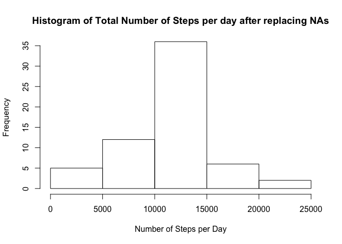

```r
#aggregating over dates
newStepsPerDay <- aggregate(dataWithNoNa$steps, by = list(Date = dataWithNoNa$date), FUN = sum)

#rename for clarity
names(newStepsPerDay)[2] <- "TotalSteps"

hist(newStepsPerDay$TotalSteps, main = "Histogram of Total Number of Steps per day after replacing NAs", xlab = "Number of Steps per Day", ylab = "Frequency", ylim = c(0,35))
```

And re-calculate the mean and median of the new data set -

```r
mean(newStepsPerDay$TotalSteps)
```

```
## [1] 10766.19
```

```r
median(newStepsPerDay$TotalSteps)
```

```
## [1] 10766.19
```

After replacing the data points that were missing with the average across days for the intervals, we see from the histogram that many intervals that had a low number of steps now have closer to the average number of steps. That is further reinforced by the fact that the median and mean are now the same, a difference from the original data set that had the mean be lower than the median. The new data set is more centered around the median and less heavy on intervals with low number of steps.

## Are there differences in activity patterns between weekdays and weekends?

In order to compare weekdays and weekends, we first need to create a new factor variable determing whether the date is a weekday or weekend.

```r
dataWithNoNa$dayType <- ifelse (weekdays(as.Date(dataWithNoNa$date)) == "Saturday" | weekdays(as.Date(dataWithNoNa$date)) == "Sunday" ,"Weekend", "Weekday")

dataWithNoNa$dayType <- as.factor(dataWithNoNa$dayType)
```

We now aggregate to find the average of intervals across weekdays and weekends -

```r
averagesWithDayType = aggregate(dataWithNoNa$steps, by =  list(interval = dataWithNoNa$interval, dayType = dataWithNoNa$dayType), FUN = mean)
```

Finally, we plot the averages across weekend and weekday in the plot below.

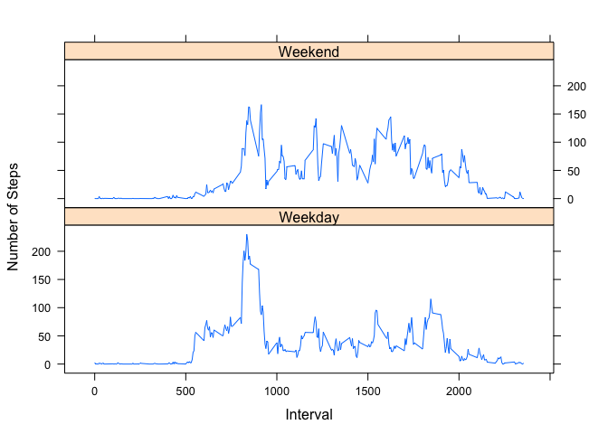

```r
library(lattice)
xyplot(averagesWithDayType$x~ averagesWithDayType$interval | averagesWithDayType$dayType, type="l", layout=c(1,2), xlab = "Interval", ylab = "Number of Steps")
```